# Final_Data_Analysis

Hoa Ninh

17 Dec 2022

# Intro

A complete data analysis on the Delomys species data.

# Data Analysis

## Questions (Q1-18)

### Q1-4: Data Exploration

#### Q1 (2 pts.): Qualitatively describe the relationship between body mass and length. Does the relationship seem linear, curved, nonexistent?

Body length and body mass appear to have positive relationship. That means Body mass increases once Body length increase. The pattern can be linear.

#### Q3 (2 pts.): Using both the histograms and normality tests, do you think the (unconditioned) body masses and body length are normally-distributed? Make sure you contrast your visual assessment of normality to the results of the numerical normality tests.

Shapiro test contrast with histogram.

Both the p value of Body mass (p-value = 4.33e-05) and Body length (p-value < 2.2e-16) in the Shapiro test are significantly smaller than 0.05. Thus, the null hypothesis is rejected or both Body mass and Body length are not normally distributed.

Histograms indicate that Body mass can be normally distributed while Body length may not to be normally distributed.

#### Q4 (2 pts.): Examine the three conditional boxplots.Describe any graphical evidence you see for body mass differences based on species and/or sex.

Species: Body mass of Delomys dorsalis is higher than Delomys sublineatus.

Sex: Body mass of male is higher than female.

In sum, Body mass is affected by species more than sex variable.

### Q7-9: Simple Linear Regression

#### Q7 (2 pts.): What is the magnitude of the mass/length relationship?

0.875

#### Q8 (2 pts.): What is the expected body length of an animal that weighs 100g?

76.125 + 100 * 0.875 = 163.625 The expected body length of an animal that weighs 100g: 163.625

#### Q9 (2 pts.): What is the expected body length of an animal that weighs 0g?

76.125 + 0 * 0.875 = 76.125 The expected body length of an animal that weighs 0g: 76.125

### Q10-13: Body Mass: Coefficient Tables

#### Q10 (1 pt.): What is the base level for sex?

female

#### Q11 (1 pt.): What is the base level for binomial?

binomial Delomys dorsalis

#### Q12 (1 pt.): Which sex is heavier? How do you know?

Males are statistical heavier than females `p value < 0.05`

#### Q13 (1 pt.): Which species is heavier? How do you know?

Delomys dorsalis are heavier than Delomys sublineatus `p value < 0.05`

### Q14-16: ANOVA Tables

#### Q14 (1 pt.): Are sex and species significant predictors for body mass?

Yes, `p value < 0.05` indicates sex and species variable are significant predictors for body mass

#### Q15 (1 pt.): Is there a significant interaction?

No, `p value > 0.05` indicates no significant interaction between sex and specie to explain body mass

### Q17-18: Model Comparison

#### Q17 (1 pt.): Which two models have the lowest AIC?

`body_mass ~ sex + binomial`: fit4 (AIC = 12896.73)

`body_mass ~ sex * binomial`: fit5 (AIC = 12898.72)

#### Q18 (4 pts.): Which of the two models with lowest AIC scores would you select? Explain your decision based on model fit and the complexity/understanding tradeoff.

I will choose `sex + binomial` given the model has the lowest AIC. The trade off that `sex + binomial` model can be complicated and affect the understanding of each variable separately on the `body mass`.

## Data Exploration

### Numerical Exploration

Create a code chunk that includes the following:

- Use summary() on the body mass and body length data columns in the Delomys data set to display summary statistics.
- Perform a test of normality on the body mass and length columns. You can use shapiro.test()

```r
# Summary statistics
summary(delomys[, c("body_mass", "body_length")])
```

```
##    body_mass       body_length
##  Min.   :  5.00   Min.   : 49.0
##  1st Qu.: 35.00   1st Qu.:106.0
##  Median : 43.00   Median :116.0
##  Mean   : 44.06   Mean   :114.7
##  3rd Qu.: 54.00   3rd Qu.:124.0
##  Max.   :105.00   Max.   :265.0
```

```r
# Test of normality on the body mass columns
shapiro.test(delomys$body_mass)
```

```
##
##  Shapiro-Wilk normality test
##
## data:  delomys$body_mass
## W = 0.99506, p-value = 4.33e-05
```

```r
# Test of normality on the body length columns
shapiro.test(delomys$body_length)
```

```
##
##  Shapiro-Wilk normality test
##
## data:  delomys$body_length
## W = 0.87609, p-value < 2.2e-16
```

### Graphical Exploration

A scatterplot of body mass and body length

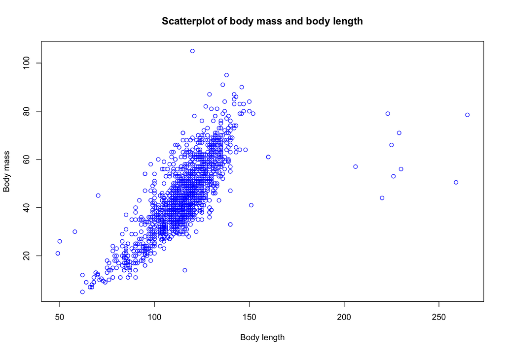

```r
plot(
    body_mass ~ body_length,
    data = delomys,
    col = "blue",
    pch = 21,
    cex = 1,
    xlab = "Body length",
    ylab = "Body mass",
    main = "Scatterplot of body mass and body length")
```

A histogram of body mass

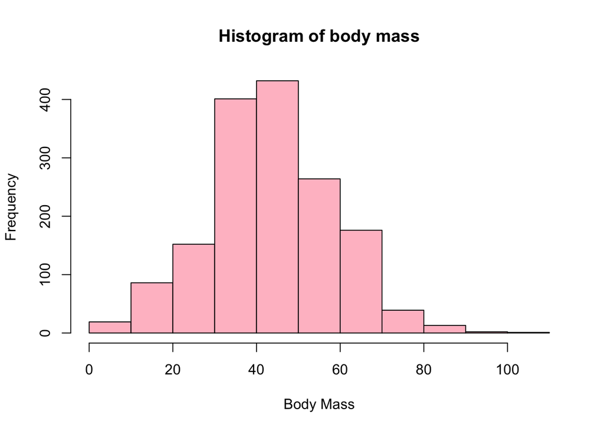

```r
hist(
  delomys$body_mass,
  main = "Histogram of body mass",
  breaks = 12,
  xlab = "Body Mass",
  ylab = "Frequency",
  col = "pink")
```

A histogram of body length

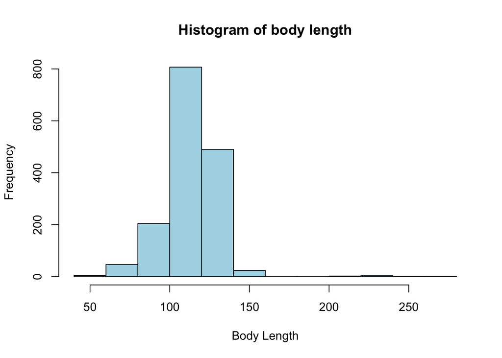

```r
hist(
  delomys$body_length,
  main = "Histogram of body length",
  breaks = 12,
  xlab = "Body Length",
  ylab = "Frequency",
  col = "lightblue")
```

A conditional boxplot of body mass, conditioned on species (column binomial)

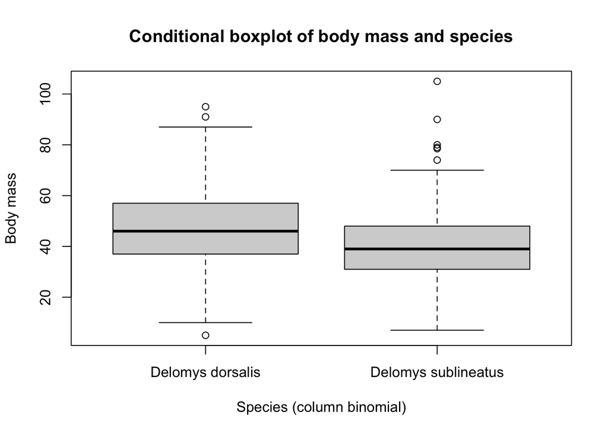

```r
boxplot(body_mass~binomial,
        data = delomys,
        main ="Conditional boxplot of body mass and species",
        xlab = "Species (column binomial)",
        ylab = "Body mass")
```

A conditional boxplot of body mass, conditioned on sex (column sex)

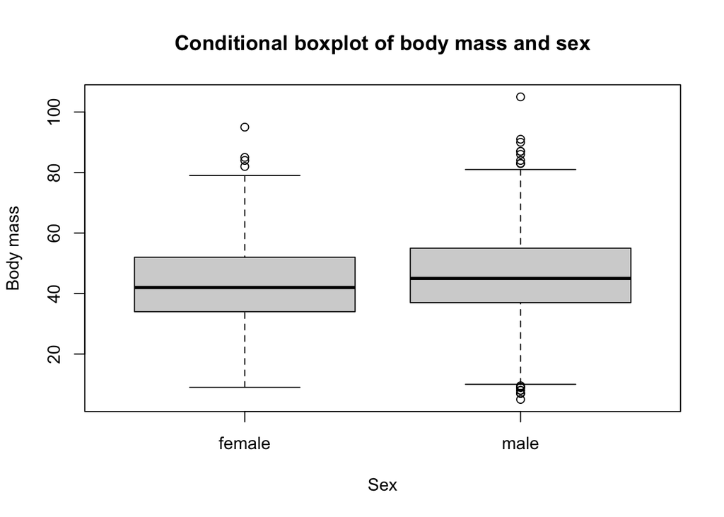

```r
boxplot(body_mass~sex,
        data = delomys,
        main ="Conditional boxplot of body mass and sex",
        xlab = "Sex",
        ylab = "Body mass")
```

A conditional boxplot of body mass, conditioned on both species and sex

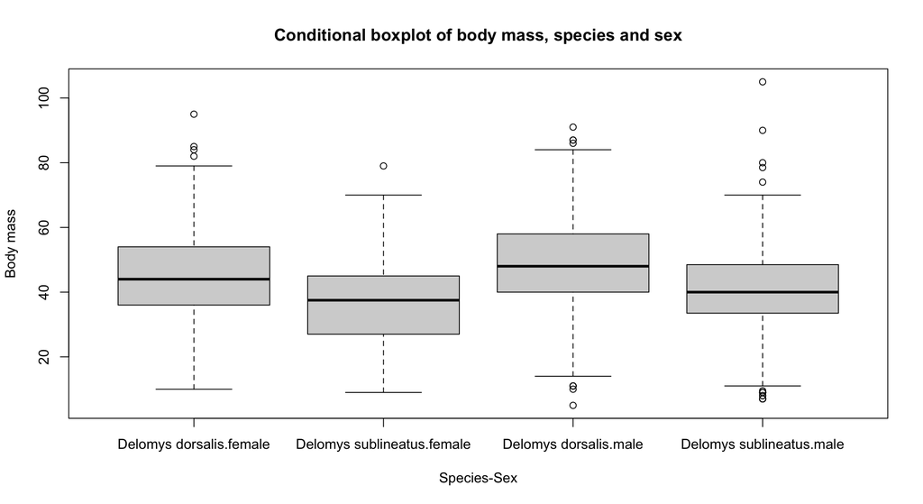

```r
boxplot(body_mass~binomial*sex,
        data = delomys,
        main ="Conditional boxplot of body mass, species and sex",
        xlab = "Species-Sex",
        ylab = "Body mass")
```

## Model Building

Using a code chunk, fit 5 models using lm() The first model predicts body length as a function of body mass The other models use the categorical variables binomial and sex to predict body mass. Save your model objects to variables called fit1, fit2, fit3, fit4, fit5.

```r
# Model 1: simple linear regression body_length ~ body_mass
fit1 = lm(body_length ~ body_mass, data= delomys)

# Model 2: 1-way ANOVA body_mass ~ sex
fit2 = lm(body_mass ~ sex, data= delomys)

# Model 3: 1-way ANOVA body_mass ~ binomial
fit3 = lm(body_mass ~ binomial, data= delomys)

# Model 4: 2-way additive ANOVA body_mass ~ sex + binomial
fit4 = lm(body_mass ~ sex + binomial, data= delomys)

# Model 5: 2-way factorial ANOVA body_mass ~ sex * binomial
fit5 = lm(body_mass ~ sex * binomial, data= delomys)
```

## Model Diagnostics

Let’s check whether our models fulfill the assumption of normality of the residuals.

First, use a graphical approach: plot histograms of the model residuals.

You can retrieve the model residuals using the `residuals()` function. For example, I could get the residuals from the first model using residuals(fit1). Use a code chunk to create histograms of the residuals of each of the 5 models.

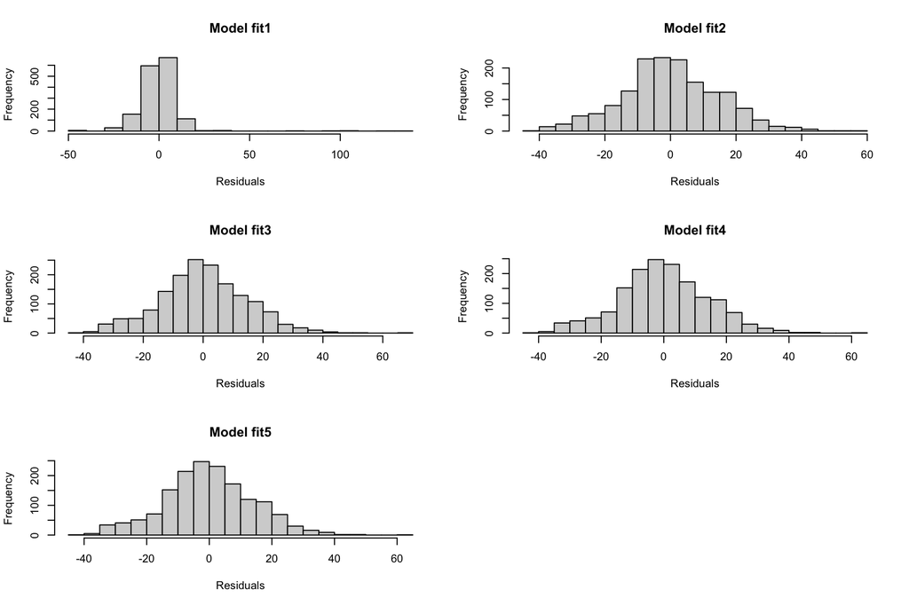

```r
# Graphical approach: plot histograms of the model residuals

par(mfrow = c(3,2))

hist(residuals(fit1),
     breaks = 20,
     main = "Model fit1",
     xlab = "Residuals")

hist(residuals(fit2),
     breaks = 20,
     main = "Model fit2",
     xlab = "Residuals")

hist(residuals(fit3),
     breaks = 20,
     main = "Model fit3",
     xlab = "Residuals")

hist(residuals(fit4),
     breaks = 20,
     main = "Model fit4",
     xlab = "Residuals")

hist(residuals(fit5),
     breaks = 20,
     main = "Model fit5",
     xlab = "Residuals")
```

```r
# use shapiro.test() on each model to test the null hypothesis that the residuals are drawn from a normally-distributed population

## Fit1
shapiro.test(residuals(fit1))
```

```
##
##  Shapiro-Wilk normality test
##
## data:  residuals(fit1)
## W = 0.73462, p-value < 2.2e-16
```

```r
## Fit 2
shapiro.test(residuals(fit2))
```

```
##
##  Shapiro-Wilk normality test
##
## data:  residuals(fit2)
## W = 0.99563, p-value = 0.0001541
```

```r
## Fit 3
shapiro.test(residuals(fit3))
```

```
##
##  Shapiro-Wilk normality test
##
## data:  residuals(fit3)
## W = 0.99535, p-value = 8.103e-05
```

```r
# Fit 4
shapiro.test(residuals(fit4))
```

```
##
##  Shapiro-Wilk normality test
##
## data:  residuals(fit4)
## W = 0.99525, p-value = 6.805e-05
```

## Model Interpretation

You can use the following code within a code chunk to print out a nicely formatted model coefficient table:

`knitr::kable(coef(summary(my_model_fit)))`

where `my_model_fit` is the name of your fitted model object.

You can use similar syntax to print a nicely formatted ANOVA table: `knitr::kable(anova(my_model_fit))`

Check out the `digits` argument to control how many decimal digits are printed.

**Model Coefficient Table**

*Body Length*

```r
# Model Coefficient Table

## Model 1: simple linear regression body_length ~ body_mass
knitr::kable(coef(summary(fit1)), digits = 4)
```

|  | Estimate | Std. Error | t value | Pr(>\|t\|) |
| --- | --- | --- | --- | --- |
| (Intercept) | 76.1247 | 0.9158 | 83.1226 | 0 |
| body_mass | 0.8755 | 0.0197 | 44.4630 | 0 |

*Body Mass*

```r
## Model 2: 1-way ANOVA body_mass ~ sex
knitr::kable(coef(summary(fit2)), digits = 4)
```

|  | Estimate | Std. Error | t value | Pr(>\|t\|) |
| --- | --- | --- | --- | --- |
| (Intercept) | 42.7115 | 0.5289 | 80.7564 | 0e+00 |
| sexmale | 2.7841 | 0.7456 | 3.7340 | 2e-04 |

```r
## Model 3: 1-way ANOVA body_mass ~ binomial
knitr::kable(coef(summary(fit3)), digits = 4)
```

|  | Estimate | Std. Error | t value | Pr(>\|t\|) |
| --- | --- | --- | --- | --- |
| (Intercept) | 46.7524 | 0.4500 | 103.8958 | 0 |
| binomialDelomys sublineatus | -7.6831 | 0.7605 | -10.1032 | 0 |

```r
## Model 4: 2-way additive ANOVA body_mass ~ sex + binomial
knitr::kable(coef(summary(fit4)), digits = 4)
```

|  | Estimate | Std. Error | t value | Pr(>\|t\|) |
| --- | --- | --- | --- | --- |
| (Intercept) | 45.0704 | 0.5556 | 81.1139 | 0 |
| sexmale | 3.7954 | 0.7260 | 5.2281 | 0 |
| binomialDelomys sublineatus | -8.1935 | 0.7610 | -10.7668 | 0 |

```r
# Model 5: 2-way factorial ANOVA body_mass ~ sex * binomial
knitr::kable(coef(summary(fit5)), digits = 4)
```

|  | Estimate | Std. Error | t value | Pr(>\|t\|) |
| --- | --- | --- | --- | --- |
| (Intercept) | 45.0555 | 0.6053 | 74.4352 | 0.0000 |
| sexmale | 3.8281 | 0.8967 | 4.2692 | 0.0000 |
| binomialDelomys sublineatus | -8.1417 | 1.1281 | -7.2172 | 0.0000 |
| sexmale:binomialDelomys sublineatus | -0.0950 | 1.5286 | -0.0622 | 0.9504 |

**ANOVA table**

*Body Length*

```r
# ANOVA table

## Model 1: simple linear regression body_length ~ body_mass
knitr::kable(anova(fit1), digits = 4)
```

|  | Df | Sum Sq | Mean Sq | F value | Pr(>F) |
| --- | --- | --- | --- | --- | --- |
| body_mass | 1 | 269388.9 | 269388.9086 | 1976.957 | 0 |
| Residuals | 1583 | 215706.6 | 136.2645 | NA | NA |

*Body Mass*

```r
## Model 2: 1-way ANOVA body_mass ~ sex
knitr::kable(anova(fit2), digits = 4)
```

|  | Df | Sum Sq | Mean Sq | F value | Pr(>F) |
| --- | --- | --- | --- | --- | --- |
| sex | 1 | 3061.678 | 3061.6779 | 13.9429 | 2e-04 |
| Residuals | 1578 | 346507.131 | 219.5863 | NA | NA |

```r
## Model 3: 1-way ANOVA body_mass ~ binomial
knitr::kable(anova(fit3), digits = 4)
```

|  | Df | Sum Sq | Mean Sq | F value | Pr(>F) |
| --- | --- | --- | --- | --- | --- |
| binomial | 1 | 21289.68 | 21289.6805 | 102.0751 | 0 |
| Residuals | 1583 | 330164.45 | 208.5688 | NA | NA |

```r
## Model 4: 2-way additive ANOVA body_mass ~ sex + binomial
knitr::kable(anova(fit4), digits = 4)
```

|  | Df | Sum Sq | Mean Sq | F value | Pr(>F) |
| --- | --- | --- | --- | --- | --- |
| sex | 1 | 3061.678 | 3061.6779 | 14.9584 | 1e-04 |
| binomial | 1 | 23727.134 | 23727.1342 | 115.9232 | 0e+00 |
| Residuals | 1577 | 322779.997 | 204.6798 | NA | NA |

```r
# Model 5: 2-way factorial ANOVA body_mass ~ sex * binomial
knitr::kable(anova(fit5), digits = 4)
```

|  | Df | Sum Sq | Mean Sq | F value | Pr(>F) |
| --- | --- | --- | --- | --- | --- |
| sex | 1 | 3061.6779 | 3061.6779 | 14.9489 | 0.0001 |
| binomial | 1 | 23727.1342 | 23727.1342 | 115.8500 | 0.0000 |
| sex:binomial | 1 | 0.7914 | 0.7914 | 0.0039 | 0.9504 |
| Residuals | 1576 | 322779.2058 | 204.8091 | NA | NA |

## Model Comparison: Body Mass

You built four different models of body mass. How do you choose the best one?

One option is to choose the model with the lowest AIC. You can calculate AIC using the appropriately named AIC() function.

Create a code chunk that calculates the AIC values for each of the body mass models.

```r
knitr::kable( AIC(fit2, fit3, fit4, fit5))
```

|  | df | AIC |
| --- | --- | --- |
| fit2 | 3 | 13006.80 |
| fit3 | 3 | 12966.36 |
| fit4 | 4 | 12896.73 |
| fit5 | 5 | 12898.72 |